# Homework 5

Yujun Pan

**1.**

This code is referenced from Canvas note on Nov 26, `first-try`.

```r
library(keras)
library(glmnet)
```

```r
library(ggplot2)
install_keras()
```

```
## Creating r-tensorflow conda environment for TensorFlow installation...
## Installing TensorFlow...
##
## Installation complete.
```

```r
mnist <- dataset_mnist()

x_train <- mnist$train$x
y_train <- mnist$train$y
x_test <- mnist$test$x
y_test <- mnist$test$y

x_train <- array_reshape(x_train, c(60000, 28^2))
x_test <- array_reshape(x_test, c(10000, 28^2))
y_train <- factor(y_train)
y_test <- factor(y_test)

s <- sample(seq_along(y_train), 1000)

fit <- cv.glmnet(x_train[s,], y_train[s], family = "multinomial")

# out-of sample
preds <- predict(fit$glmnet.fit, x_test, s = fit$lambda.min,
                 type = "class")
t <- table(as.vector(preds), y_test)
sum(diag(t)) / sum(t)
```

```
## [1] 0.8538
```

```r
# 0.8424

# in-sample test
preds.train <- predict(fit$glmnet.fit, x_train[s, ], s = fit$lambda.min, type = "class")
t_train <- table(as.vector(preds.train), y_train[s])
sum(diag(t_train)) / sum(t_train)
```

```
## [1] 1
```

```r
## 0.988
```

Now add intensity as extra feature. Reference: http://apapiu.github.io/2016-01-02-minst/

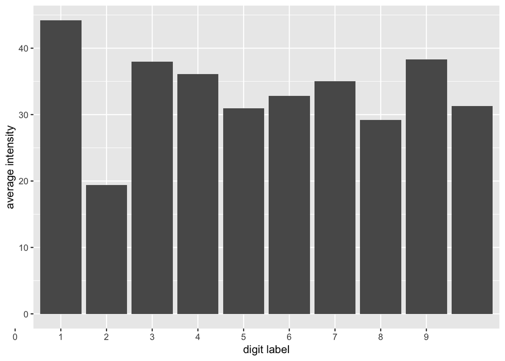

```r
intensity <- apply(x_train,1,mean)
intensity <- aggregate(intensity,by=list(y_train),FUN = mean)

ggplot(data =intensity,aes(x=Group.1,y=x))+geom_bar(stat = "identity") +   scale_x_discrete(limits=0:9)+xlab("digit label")+ylab("average intensity")
```

Add intensity to the features

```r
intensity <- apply(x_train,1,mean)
intensity<-as.vector(intensity)
x_train<-cbind(x_train,intensity)
x_test<-cbind(x_test,as.vector(apply(x_test,1,mean)))
```

Test out of sample accuracy.

```r
fit <- cv.glmnet(x_train[s,], y_train[s], family = "multinomial")
preds <- predict(fit$glmnet.fit, x_test, s = fit$lambda.min,
                 type = "class")
t <- table(as.vector(preds), y_test)
sum(diag(t)) / sum(t)
```

```
## [1] 0.8514
```

```r
# 0.8447
```

**2.** CASL Number 4 in Exercises 8.11

Adjust the kernel size, and any other parameters you think are useful, in the convolutional neural network for EMNIST in Section 8.10.4. Can you improve on the classification rate?

I’m going to modify based on coade from Nov 26 `s.r` that was uploaded on Canvas, which is taken from https://keras.rstudio.com/articles/examples/mnist_cnn.html

Professor Kane has given us permission to use mnist, since emnist was too big to knit.

```r
# Data Preparation -----------------------------------------------------
batch_size <- 128
num_classes <- 10
epochs <- 2

# Input image dimensions
img_rows <- 28
img_cols <- 28

# The data, shuffled and split between train and test sets
mnist <- dataset_mnist()
x_train <- mnist$train$x
y_train <- mnist$train$y
x_test <- mnist$test$x
y_test <- mnist$test$y

# Redefine  dimension of train/test inputs
x_train <- array_reshape(x_train, c(nrow(x_train), img_rows, img_cols, 1))
x_test <- array_reshape(x_test, c(nrow(x_test), img_rows, img_cols, 1))
input_shape <- c(img_rows, img_cols, 1)

# Transform RGB values into [0,1] range
x_train <- x_train / 255
x_test <- x_test / 255

cat('x_train_shape:', dim(x_train), '\n')
```

```
## x_train_shape: 60000 28 28 1
```

```r
cat(nrow(x_train), 'train samples\n')
```

```
## 60000 train samples
```

```r
cat(nrow(x_test), 'test samples\n')
```

```
## 10000 test samples
```

```r
# Convert class vectors to binary class matrices
y_train <- to_categorical(y_train, num_classes)
y_test <- to_categorical(y_test, num_classes)

# Define Model -----------------------------------------------------------

# Define model
model <- keras_model_sequential() %>%
  layer_conv_2d(filters = 32, kernel_size = c(3,3), activation = 'relu',
                input_shape = input_shape) %>%
  layer_conv_2d(filters = 64, kernel_size = c(3,3), activation = 'relu') %>%
  layer_max_pooling_2d(pool_size = c(2, 2)) %>%
  layer_dropout(rate = 0.25) %>%
  layer_flatten() %>%
  layer_dense(units = 128, activation = 'relu') %>%
  layer_dropout(rate = 0.5) %>%
  layer_dense(units = num_classes, activation = 'softmax')

# Compile model
model %>% compile(
  loss = loss_categorical_crossentropy,
  optimizer = optimizer_adadelta(),
  metrics = c('accuracy')
)

# Train model
model %>% fit(
  x_train, y_train,
  batch_size = batch_size,
  epochs = epochs,
  validation_split = 0.2
)

scores <- model %>% evaluate(
  x_test, y_test, verbose = 0
)

# Output metrics
cat('Test loss:', scores[[1]], '\n') #0.04465571
```

```
## Test loss: 0.04312352
```

```r
cat('Test accuracy:', scores[[2]], '\n') #0.9849
```

```
## Test accuracy: 0.985
```

In Professor Kane’s example, we use kernel size = (3,3) and drop out rate is 0.25, the classification accuracy is 0.9849.

Now I’m going to vary kernel size to (2,2) and (5,5), to save time I’m going to set eval=FALSE for the following section.

```r
model <- keras_model_sequential() %>%
  layer_conv_2d(filters = 32, kernel_size = c(2,2), activation = 'relu',
                input_shape = input_shape) %>%
  layer_conv_2d(filters = 64, kernel_size = c(2,2), activation = 'relu') %>%
  layer_max_pooling_2d(pool_size = c(2, 2)) %>%
  layer_dropout(rate = 0.25) %>%
  layer_flatten() %>%
  layer_dense(units = 128, activation = 'relu') %>%
  layer_dropout(rate = 0.5) %>%
  layer_dense(units = num_classes, activation = 'softmax')

# Compile model
model %>% compile(
  loss = loss_categorical_crossentropy,
  optimizer = optimizer_adadelta(),
  metrics = c('accuracy')
)

# Train model
model %>% fit(
  x_train, y_train,
  batch_size = batch_size,
  epochs = epochs,
  validation_split = 0.2
)

scores <- model %>% evaluate(
  x_test, y_test, verbose = 0
)

# Output metrics
cat('Test loss:', scores[[1]], '\n') # 0.06600517
cat('Test accuracy:', scores[[2]], '\n') #0.9784
```

When kernel size = (2,2) the accuracy decreases to 0.9784 slightly. Now we choose a larger size = (5,5)

```r
model <- keras_model_sequential() %>%
  layer_conv_2d(filters = 32, kernel_size = c(5,5), activation = 'relu',
                input_shape = input_shape) %>%
  layer_conv_2d(filters = 64, kernel_size = c(5,5), activation = 'relu') %>%
  layer_max_pooling_2d(pool_size = c(5, 5)) %>%
  layer_dropout(rate = 0.25) %>%
  layer_flatten() %>%
  layer_dense(units = 128, activation = 'relu') %>%
  layer_dropout(rate = 0.5) %>%
  layer_dense(units = num_classes, activation = 'softmax')

# Compile model
model %>% compile(
  loss = loss_categorical_crossentropy,
  optimizer = optimizer_adadelta(),
  metrics = c('accuracy')
)

# Train model
model %>% fit(
  x_train, y_train,
  batch_size = batch_size,
  epochs = epochs,
  validation_split = 0.2
)

scores <- model %>% evaluate(
  x_test, y_test, verbose = 0
)

# Output metrics
cat('Test loss:', scores[[1]], '\n') # 0.06600517
cat('Test accuracy:', scores[[2]], '\n') #0.9784
```

# 3. CASL Number 8 in Exercises 8.11

```r
# Create list of weights to describe a dense neural network.
# Args: sizes: A vector giving the size of each layer, including the input and output layers.
# Returns: A list containing initialized weights and biases.
casl_nn_make_weights <- function(sizes) {
  L <- length(sizes) - 1L
  weights <- vector("list", L)
  for (j in seq_len(L)) {
    w <- matrix(rnorm(sizes[j] * sizes[j + 1L]), ncol = sizes[j], nrow = sizes[j + 1L])
    weights[[j]] <- list(w=w, b=rnorm(sizes[j + 1L]))
  }
  weights
}


# Apply a rectified linear unit (ReLU) to a vector/matrix.
# Args: v: A numeric vector or matrix.
# Returns: The original input with negative values truncated to zero.
casl_util_ReLU <- function(v) {
  v[v < 0] <- 0
  v
}
# Apply derivative of the rectified linear unit (ReLU).
# Args: v: A numeric vector or matrix.
# Returns: Sets positive values to 1 and negative values to zero.
casl_util_ReLU_p <- function(v) {
  p <- v * 0
  p[v > 0] <- 1
  p
}

# Derivative of the mean absolute deviation (MAD) function.
# Args: y: A numeric vector of responses.
#       a: A numeric vector of predicted responses.
# Returns: Returned current derivative the MAD function.
casl_util_mad_p <- function(y, a) {
  derloss <- c()
  for (i in 1:length(a)) {
    if (a[i] >= mean(y)) derloss[i]=1
    else derloss[i]=-1
  }
  return(derloss)
}
# Apply forward propagation to a set of NN weights and biases.
# Args: x: A numeric vector representing one row of the input.
#       weights: A list created by casl_nn_make_weights.
#       sigma: The activation function.
# Returns: A list containing the new weighted responses (z) and activations (a).
casl_nn_forward_prop <- function(x, weights, sigma) {
  L <- length(weights)
  z <- vector("list", L)
  a <- vector("list", L)
  for (j in seq_len(L)) {
    a_j1 <- if(j == 1) x else a[[j - 1L]]
    z[[j]] <- weights[[j]]$w %*% a_j1 + weights[[j]]$b
    a[[j]] <- if (j != L) sigma(z[[j]]) else z[[j]]
  }
  list(z=z, a=a)
}
# Apply backward propagation algorithm.
# Args: x: A numeric vector representing one row of the input.
#       y: A numeric vector representing one row of the response.
#       weights: A list created by casl_nn_make_weights.
#       f_obj: Output of the function casl_nn_forward_prop.
#       sigma_p: Derivative of the activation function.
#       f_p: Derivative of the loss function.
# Returns: A list containing the new weighted responses (z) and activations (a).
casl_nn_backward_prop <- function(x, y, weights, f_obj, sigma_p, f_p) {
  z <- f_obj$z
  a <- f_obj$a
  L <- length(weights)
  grad_z <- vector("list", L)
  grad_w <- vector("list", L)
  for (j in rev(seq_len(L))) {
    if (j == L) {
      grad_z[[j]] <- f_p(y, a[[j]])
      }
    else {
      grad_z[[j]] <- (t(weights[[j + 1]]$w) %*% grad_z[[j + 1]]) * sigma_p(z[[j]])
      }
    a_j1 <- if(j == 1) x else a[[j - 1L]]
    grad_w[[j]] <- grad_z[[j]] %*% t(a_j1)
  }
  list(grad_z=grad_z, grad_w=grad_w)
}
# Apply stochastic gradient descent (SGD) to estimate NN.
# Args: X: A numeric data matrix.
#       y: A numeric vector of responses.
#       sizes: A numeric vector giving the sizes of layers in the neural network.
#       epochs: Integer number of epochs to computer.
#       eta: Positive numeric learning rate.
#       weights: Optional list of starting weights.
# Returns: A list containing the trained weights for the network.
casl_nn_sgd <- function(X, y, sizes, epochs, eta, weights=NULL) {
  if (is.null(weights)) {
    weights <- casl_nn_make_weights(sizes)
    }
  for (epoch in seq_len(epochs)) {
    for (i in seq_len(nrow(X))) {
      f_obj <- casl_nn_forward_prop(X[i,], weights, casl_util_ReLU)
      b_obj <- casl_nn_backward_prop(X[i,], y[i,], weights, f_obj, casl_util_ReLU_p, casl_util_mad_p)
      for (j in seq_along(b_obj)) {
        weights[[j]]$b <- weights[[j]]$b - eta * b_obj$grad_z[[j]]
        weights[[j]]$w <- weights[[j]]$w - eta * b_obj$grad_w[[j]]
      }
    }
  }
  weights
}
# Predict values from a training neural network.
# Args: weights: List of weights describing the neural network.
#       X_test: A numeric data matrix for the predictions.
# Returns: A matrix of predicted values.
casl_nn_predict <- function(weights, X_test) {
  p <- length(weights[[length(weights)]]$b)
  y_hat <- matrix(0, ncol = p, nrow = nrow(X_test))
  for (i in seq_len(nrow(X_test))) {
    a <- casl_nn_forward_prop(X_test[i,], weights, casl_util_ReLU)$a
    y_hat[i, ] <- a[[length(a)]]
  }
  y_hat
}


# Apply stochastic gradient descent (SGD) for multinomial NN.
#
# Args:
#     X: A numeric data matrix.
#     y: A numeric vector of responses.
#     sizes: A numeric vector giving the sizes of layers in
#            the neural network.
#     epochs: Integer number of epochs to computer.
#     eta: Positive numeric learning rate.
#     mu: Non-negative momentum term.
#     l2: Non-negative penalty term for l2-norm.
#     weights: Optional list of starting weights.
#
# Returns:
#     A list containing the trained weights for the network.
casl_nnmulti_sgd <- function(X, y, sizes, epochs, eta, mu=0, l2=0, weights = NULL) {
  if (is.null(weights))
  {
    weights <- casl_nn_make_weights_mu(sizes)
  }
  for (epoch in seq_len(epochs))
  {
    for (i in seq_len(nrow(X)))
    {
      f_obj <- casl_nnmulti_forward_prop(X[i, ], weights,
                                         casl_util_ReLU)
      b_obj <- casl_nnmulti_backward_prop(X[i, ], y[i, ],
                                      weights, f_obj,
                                      casl_util_ReLU_p)
  for (j in seq_along(b_obj))
  {
    weights[[j]]$b <- weights[[j]]$b -
                        eta * b_obj$grad_z[[j]]
    weights[[j]]$v <- mu * weights[[j]]$v -
                      eta * b_obj$grad_w[[j]]
  weights[[j]]$w <- (1 - eta * l2) *
                    weights[[j]]$w +
                         weights[[j]]$v
  } }
  }
weights
}
```

Simulating data based on textbook page 232.

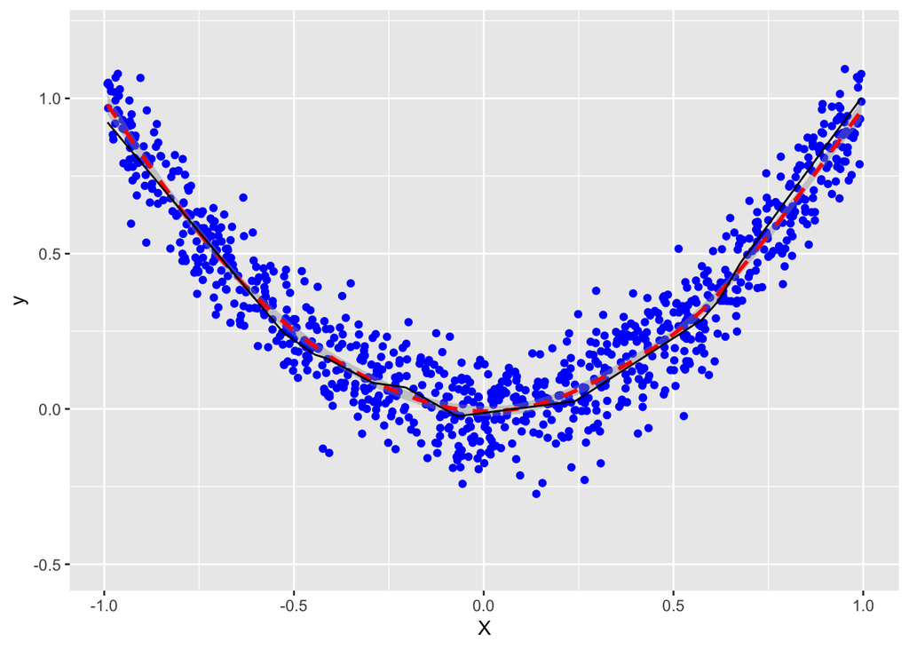

```r
set.seed(24232)
X <- matrix(runif(1000, min=-1, max=1), ncol=1)
y <- X[, 1, drop = FALSE]^2 + rnorm(1000, sd = 0.1)

# add noise according to lecture code on Nov 26. Use uniform distribution
# trying to be careful, adding as less noise as possible to maintain the U-shape
y[sample(1000, 60)] <- c(runif(60, 3, 6))

#Fit the model:
weights <- casl_nn_sgd(X, y, sizes=c(1, 25, 1), epochs=25, eta=0.01)
y_pred <- casl_nn_predict(weights, X)

#Visualize the model prediction:
library(ggplot2)
sim <- data.frame(X, y, y_pred)

#Exclude outliers in the plot:
ggplot(sim, aes(x=X, y=y)) +
  geom_point(color='blue') +
  ylim(-0.5, 1.2) +
  geom_smooth(color='red', linetype='dashed') +
  geom_line(aes(x=X, y=y_pred))
```

Neural network using mean absolute deviation as a loss function works well.